# Lathyrus vernus function-based MPMs

#### Step 3. Tests of history, and vital rate modeling

Next we will run the `modelsearch` function with the new vertical dataset, first for the ahistorical model set and then for the historical model set. This function will develop our best-fit vital rate models for us, and also allow us to test whether individual history is a significant influence on vital rates. This function looks simple, but it automates several crucial and complex tasks in MPM analysis. Specifically, it automates 1) the building of global models for each vital rate requested, 2) the exhaustive construction of all reduced models, and 3) the selection of the best-fit models.

Let’s look at some of the options that we will utilize for this purpose (please note that this list includes only some of the options actually offered by the function - further options are shown in the documentation for `modelsearch()`, and further theoretical details are shown in the `Basic theory and concepts` vignette).

**historical**: Setting this to TRUE or FALSE tells R whether to include state in time *t*-1 in the global models.

**approach**: This option tells R whether to use generalized linear models (`glm`), in which all factors are treated as fixed, or mixed effects models (`mixed`), in which factors are treated as either fixed or random (most notably, time, patch, and individual identity can be treated as random). We encourage users to use the latter option, as it accounts for pseudoreplication, but the former approach is more common.

**suite**: This tells R which factors to include in the global model. Possible values include `size`, which includes size only; `rep`, which includes reproductive status only; `main`, which includes both size and reproductive status as main effects only; `full`, which includes both size and reproductive status and all two-way interactions; and `const`, which includes only an intercept. These factors are in addition to individual identity, patch, and time.

**vitalrates**: This option tells R which vital rates to model. The default is to model survival, size, and fecundity, but users can also model observation status and reproduction status.

**juvestimate**: This optional term tells R the name of the juvenile stage transitioning to maturity, in cases where the dataset includes data on juveniles.

**juvsize**: This optional term denotes whether size should be used as an independent term in models involving transition from the juvenile stage.

**bestfit**: This describes whether the best-fit model should be chosen as the model with the lowest AICc (`AICc`) or as the most parsimonious model (`AICc&k`), where the latter is the model that has the fewest estimated parameters and is within 2 AICc units of the model with the lowest AICc. We encourage users to choose the latter. This is the default setting, and is more in-line with model selection protocols preferred by information theorists (Burnham and Anderson 2002)..

**sizedist**: This designates the distribution used for size. The options include `gaussian`, `poisson`, and `negbin`, the last of which refers to the negative binomial distribution.

**fecdist**: This designates the distribution used for fecundity. The options include `gaussian`, `poisson`, and `negbin`, the last of which refers to the negative binomial distribution.

**fectime**: This designates whether fecundity is estimated within time *t* (the default) or time *t*+1. Plant ecologists are likely to choose the former, since fecundity is typically estimated via a proxy such as flowers, fruit, or seed produced. Wildlife ecologists might choose the latter, since fecundity may be best estimated as a count of actual juveniles within nests, burrows, or other family structures.

**size.zero**: This designates whether the size distribution should be zero-inflated. Only applies to the Poisson and negative binomial distributions.

**fec.zero**: This designates whether the fecundity distribution should be zero-inflated. Only applies to the Poisson and negative binomial distributions.

**indiv**: This should include the name of the variable corresponding to individual identity in the vertical dataset.

**patch**: This should include the name of the variable corresponding to patch identity in the vertical dataset.

**year**: This should include the name of the variable corresponding to time *t* in the vertical dataset.

**year.as.random**: This tells R whether to treat year as a random factor, and is only used when `approach = "mixed"`.

**patch.as.random**: This tells R whether to treat patch identity as a random factor, and is only used when `approach = "mixed"`.

**show.model.tables**: This tells R to include the full dredge model tables showing all models developed and their associated AICc values.

**quiet**: This tells R to silence guidepost statements and most warning messages. Only warnings incurred in model testing will be visible, including warnings from the testing of global models and those from the testing of reduced models produced during model dredging.

In addition, there are other options that provide flexibility in handling datasets with different designations for key variables, and allowing manual designation of stages.

This function is useful not just because it develops the models that we can use to estimate function-based MPMs, but because it provides a test of whether individual history affects demography. Setting `historical = TRUE` fits size and/or reproductive status in time *t*-1 into global models. If any of the resulting best-fit vital rate models include one of these terms, then we see a significant effect of individual history on demography, and we have a reason to proceed with historical MPM analysis. Here, we will build both ahistorical and historical models for comparison.

First we will create the ahistorical model set.

```r
lathmodelsln2 <- modelsearch(lathvertln, historical = FALSE, approach = "mixed",
                             suite = "full", juvestimate = "Sdl", bestfit = "AICc&k",
                             vitalrates = c("surv", "obs", "size", "repst", "fec"),
                             sizedist = "gaussian", fecdist = "negbin", fec.zero = TRUE,
                             indiv = "individ", patch = "patchid", year = "year2",
                             year.as.random = TRUE, patch.as.random = TRUE, juvsize = TRUE,
                             quiet = TRUE)
```

```
#> boundary (singular) fit: see ?isSingular
#> boundary (singular) fit: see ?isSingular
#> boundary (singular) fit: see ?isSingular
#> boundary (singular) fit: see ?isSingular
```

The output can be rather verbose, and so we have limited it with the `quiet = TRUE` option. The function was developed to provide text marker posts of what the function is doing and what it has accomplished, as well as to show all warnings from all workhorse functions used. Because we used the `mixed` approach here, this includes warnings originating from estimating mixed linear models with package `lme4` (Bates et al. 2015). It also shows warnings originating from the `dredge()` function of package `MuMIn` (Bartoń 2014), which is the core function used in model building and AICc estimation. We encourage users to get familiar with interpreting these warnings and assessing the degree to which they impact their own analyses.

In developing these linear models, the `modelsearch()` function set up a series of nested datasets for use in estimating vital rates as conditional rates and probabilities. The exact subsets created depend on which parameters are called for. It is important to consider which are required, and particular attention needs to be paid if there are size classes with sizes of 0. In these situations, it is best to consider a size of 0 as unobservable, and so to introduce observation status as a vital rate. This sets up datasets for size estimation that do not include 0 in the response term, because all 0 responses are already absorbed by observation status.

Let’s take a peek at the summary for the model selection output. This condenses the output to the necessities.

```r
summary(lathmodelsln2)
```

```
#> This LefkoMod object includes 8 linear models.
#> Best-fit model criterion used: AICc&k
#>
#> ────────────────────────────────────────────────────────────────────────────────
#> Survival model:
#> Generalized linear mixed model fit by maximum likelihood (Laplace Approximation) ['glmerMod']
#>  Family: binomial  ( logit )
#> Formula: alive3 ~ repstatus2 + sizea2 + (1 | year2) + (1 | patchid) +      (1 | individ)
#>    Data: surv.data
#>       AIC       BIC    logLik  deviance  df.resid
#>  916.4218  950.7233 -452.2109  904.4218      2240
#> Random effects:
#>  Groups  Name        Std.Dev.
#>  individ (Intercept) 0.4844333
#>  patchid (Intercept) 0.2554894
#>  year2   (Intercept) 0.0008752
#> Number of obs: 2246, groups:  individ, 257; patchid, 6; year2, 3
#> Fixed Effects:
#> (Intercept)   repstatus2       sizea2
#>      2.0461       1.7264       0.1469
#>
#> ────────────────────────────────────────
#>
#> Observation model:
#> Generalized linear mixed model fit by maximum likelihood (Laplace Approximation) ['glmerMod']
#>  Family: binomial  ( logit )
#> Formula: obsstatus3 ~ (1 | year2) + (1 | patchid) + (1 | individ)
#>    Data: obs.data
#>       AIC       BIC    logLik  deviance  df.resid
#> 1342.9524 1365.5910 -667.4762 1334.9524      2117
#> Random effects:
#>  Groups  Name        Std.Dev.
#>  individ (Intercept) 6.46e-05
#>  patchid (Intercept) 3.61e-01
#>  year2   (Intercept) 0.00e+00
#> Number of obs: 2121, groups:  individ, 254; patchid, 6; year2, 3
#> Fixed Effects:
#> (Intercept)
#>        2.24
#> optimizer (Nelder_Mead) convergence code: 0 (OK) ; 0 optimizer warnings; 1 lme4 warnings
```

[output cut: 185 more lines]

```
#>
#> ────────────────────────────────────────────────────────────────────────────────
#>
#> Quality control:
#>
#> Survival estimated with 257 individuals and 2246 individual transitions.
#> Observation estimated with 254 individuals and 2121 individual transitions.
#> Size estimated with 254 individuals and 1916 individual transitions.
#> Reproductive status estimated with 254 individuals and 1916 individual transitions.
#> Fecundity estimated with 128 individuals and 599 individual transitions.
#> Juvenile survival estimated with 187 individuals and 281 individual transitions.
#> Juvenile observation estimated with 154 individuals and 210 individual transitions.
#> Juvenile size estimated with 144 individuals and 193 individual transitions.
#> Juvenile reproduction probability not estimated.
#> NULL
```

The best-fit models vary a bit in complexity. For example, survival is influenced by size and reproductive status in the current year, as well as by patch, individual identity, and year, while observation status is not influenced by size. We can see these models explicitly, as well as the model tables developed, by calling them directly from the lefkoMod object. Here is the best-fit model for fecunity.

```r
lathmodelsln2$fecundity_model
```

```
#> Formula:          feca2 ~ sizea2 + (1 | year2) + (1 | patchid) + (1 | individ)
#> Zero inflation:         ~sizea2 + (1 | year2) + (1 | patchid) + (1 | individ)
#> Data: fec.data
#>       AIC       BIC    logLik  df.resid
#>  2473.717  2522.065 -1225.858       588
#> Random-effects (co)variances:
#>
#> Conditional model:
#>  Groups  Name        Std.Dev.
#>  year2   (Intercept) 0.1317041
#>  patchid (Intercept) 0.0000503
#>  individ (Intercept) 0.3009980
#>
#> Zero-inflation model:
#>  Groups  Name        Std.Dev.
#>  year2   (Intercept) 0.6680
#>  patchid (Intercept) 0.2256
#>  individ (Intercept) 0.4795
#>
#> Number of obs: 599 / Conditional model: year2, 3; patchid, 6; individ, 128 / Zero-inflation model: year2, 3; patchid, 6; individ, 128
#>
#> Overdispersion parameter for nbinom2 family ():  2.4
#>
#> Fixed Effects:
#>
#> Conditional model:
#> (Intercept)       sizea2
#>     -2.4358       0.6476
#>
#> Zero-inflation model:
#> (Intercept)       sizea2
#>      4.0764      -0.5421
```

This model assumes a zero-inflated negative binomial distribution, and so is actually composed of two models - a negative binomial model that covers non-zero cases, and a zero-inflation binomial model that predicts the probability of a 0 under a separate process from the count process. This best-fit model shows the best-fit for both components. The other models in `lathmodelsln2` are less complex, being composed of a single linear model predicting all cases of the response.

Now let’s estimate the historical model set. This search will take more time, because the inclusion of status in time *t*-1 (and all two-way interactions when `suite = "full"`) increases the number of models that the `dredge` function will build and compare. The inclusion of these terms may also create more warnings as the function proceeds. Please also note that we include `quiet = TRUE` here, which prevents the model selection protocol from issuing warnings and most diagnostic messages. We do this only because the model selection will generate a particularly verbose list of warnings in this case. Normally it is best to stick with the default, `quiet = FALSE`.

```r
lathmodelsln3 <- modelsearch(lathvertln, historical = TRUE, approach = "lme4", suite = "full",
                          vitalrates = c("surv", "obs", "size", "repst", "fec"), juvestimate = "Sdl",
                          bestfit = "AICc&k", sizedist = "gaussian", fecdist = "negbin",
                          fec.zero = TRUE, indiv = "individ", patch = "patchid", year = "year2",
                          year.as.random = TRUE, patch.as.random = TRUE, juvsize = TRUE,
                          show.model.tables = TRUE, quiet = TRUE)
```

[output not shown]

```r
summary(lathmodelsln3)
```

```
#> This LefkoMod object includes 8 linear models.
#> Best-fit model criterion used: AICc&k
#>
#> ────────────────────────────────────────────────────────────────────────────────
#> Survival model:
#> Generalized linear mixed model fit by maximum likelihood (Laplace Approximation) ['glmerMod']
#>  Family: binomial  ( logit )
#> Formula: alive3 ~ repstatus1 + repstatus2 + sizea1 + sizea2 + (1 | year2) +
#>     (1 | patchid) + (1 | individ) + repstatus2:sizea2 + sizea1:sizea2
#>    Data: surv.data
#>       AIC       BIC    logLik  deviance  df.resid
#>  877.4442  934.6133 -428.7221  857.4442      2236
#> Random effects:
#>  Groups  Name        Std.Dev.
#>  individ (Intercept) 0.1830
#>  patchid (Intercept) 0.2496
#>  year2   (Intercept) 0.3926
#> Number of obs: 2246, groups:  individ, 257; patchid, 6; year2, 3
#> Fixed Effects:
#>       (Intercept)         repstatus1         repstatus2             sizea1             sizea2  repstatus2:sizea2      sizea1:sizea2
#>           1.02667            1.84052           11.69226            0.46047            0.27446           -1.43729           -0.06948
#> optimizer (Nelder_Mead) convergence code: 0 (OK) ; 0 optimizer warnings; 1 lme4 warnings
#>
#> ────────────────────────────────────────
#>
#> Observation model:
#> Generalized linear mixed model fit by maximum likelihood (Laplace Approximation) ['glmerMod']
#>  Family: binomial  ( logit )
#> Formula: obsstatus3 ~ (1 | year2) + (1 | patchid) + (1 | individ)
#>    Data: obs.data
#>       AIC       BIC    logLik  deviance  df.resid
#> 1342.9524 1365.5910 -667.4762 1334.9524      2117
#> Random effects:
#>  Groups  Name        Std.Dev.
#>  individ (Intercept) 6.46e-05
#>  patchid (Intercept) 3.61e-01
#>  year2   (Intercept) 0.00e+00
#> Number of obs: 2121, groups:  individ, 254; patchid, 6; year2, 3
#> Fixed Effects:
#> (Intercept)
```

[output cut: 191 more lines]

```
#>
#> ────────────────────────────────────────────────────────────────────────────────
#>
#> Quality control:
#>
#> Survival estimated with 257 individuals and 2246 individual transitions.
#> Observation estimated with 254 individuals and 2121 individual transitions.
#> Size estimated with 254 individuals and 1916 individual transitions.
#> Reproductive status estimated with 254 individuals and 1916 individual transitions.
#> Fecundity estimated with 128 individuals and 599 individual transitions.
#> Juvenile survival estimated with 187 individuals and 281 individual transitions.
#> Juvenile observation estimated with 154 individuals and 210 individual transitions.
#> Juvenile size estimated with 144 individuals and 193 individual transitions.
#> Juvenile reproduction probability not estimated.
#> NULL
```

This summary reveals some similarities, but also many differences. Historical models incorporate a further time back in the global model, so some of the best-fit models may have historical terms in them. Here, we see some of these historical terms in the models of survival, size, reproduction status, and fecundity. We also see that incorporating a time back ends up changing the model best-fit model structure such that reproductive status also becomes an important determinant of some vital rates, even where it was absent in the ahistorical case. This suggests that individual history is important to the demography of this population, and should not be ignored.

Now we are ready to estimate matrices.

#### Step 4. MPM estimation

For instructional purposes, we will make both ahistorical and historical MPMs. We will start by estimating the ahistorical set of matrices. Notice that we are matching the ahistorical matrix creation function, `flefko2()`, with the appropriate ahistorical input, including the ahistorical lefkoMod object `lathmodelsln2`. Model sets that include historical terms should not be used to create ahistorical matrices, since the coefficients in the best-fit models are estimated assuming a specific model structure. Historical vital rate models may yield biased results if used to construct ahistorical matrices.

```r
lathmat2ln <- flefko2(stageframe = lathframeln, modelsuite = lathmodelsln2,
                      data = lathvertln, repmatrix = lathrepmln, overwrite = lathover2,
                      year.as.random = FALSE, patch.as.random = FALSE)
summary(lathmat2ln)
```

```
#>
#> This ahistorical lefkoMat object contains 18 matrices.
#>
#> Each matrix is a square matrix with 21 rows and columns, and a total of 441 elements.
#> A total of 6732 survival transitions were estimated, with 374 per matrix.
#> A total of 324 fecundity transitions were estimated, with 18 per matrix.
#>
#> Vital rate modeling quality control:
#>
#> Survival estimated with 257 individuals and 2246 individual transitions.
#> Observation estimated with 254 individuals and 2121 individual transitions.
#> Size estimated with 254 individuals and 1916 individual transitions.
#> Reproductive status estimated with 254 individuals and 1916 individual transitions.
#> Fecundity estimated with 128 individuals and 599 individual transitions.
#> Juvenile survival estimated with 187 individuals and 281 individual transitions.
#> Juvenile observation estimated with 154 individuals and 210 individual transitions.
#> Juvenile size estimated with 144 individuals and 193 individual transitions.
#> Juvenile reproduction probability not estimated.
#> NULL
```

Let’s take a look at a portion of the first of these matrices.

```r
print(lathmat2ln$A[[1]][,1:5], digits = 3)
```

```
#>        [,1]     [,2]     [,3]     [,4]     [,5]
#>  [1,] 0.345 0.00e+00 0.00e+00 0.00e+00 0.00e+00
#>  [2,] 0.054 3.85e-20 0.00e+00 0.00e+00 0.00e+00
#>  [3,] 0.000 2.93e-05 6.66e-02 6.75e-02 6.82e-02
#>  [4,] 0.000 4.56e-01 7.32e-02 3.54e-02 1.46e-02
#>  [5,] 0.000 8.11e-03 2.36e-01 1.64e-01 9.79e-02
#>  [6,] 0.000 1.67e-07 3.10e-01 3.12e-01 2.68e-01
#>  [7,] 0.000 4.01e-15 1.67e-01 2.42e-01 3.01e-01
#>  [8,] 0.000 1.11e-25 3.68e-02 7.70e-02 1.38e-01
#>  [9,] 0.000 3.60e-39 3.32e-03 1.00e-02 2.58e-02
#> [10,] 0.000 1.35e-55 1.22e-04 5.32e-04 1.98e-03
#> [11,] 0.000 5.87e-75 1.84e-06 1.16e-05 6.20e-05
#> [12,] 0.000 2.96e-97 1.14e-08 1.03e-07 7.95e-07
#> [13,] 0.000 0.00e+00 1.95e-04 2.15e-04 2.04e-04
#> [14,] 0.000 0.00e+00 6.28e-04 1.00e-03 1.36e-03
#> [15,] 0.000 0.00e+00 8.28e-04 1.90e-03 3.73e-03
#> [16,] 0.000 0.00e+00 4.46e-04 1.48e-03 4.18e-03
#> [17,] 0.000 0.00e+00 9.82e-05 4.69e-04 1.92e-03
#> [18,] 0.000 0.00e+00 8.85e-06 6.10e-05 3.59e-04
#> [19,] 0.000 0.00e+00 3.26e-07 3.24e-06 2.75e-05
#> [20,] 0.000 0.00e+00 4.92e-09 7.04e-08 8.63e-07
#> [21,] 0.000 0.00e+00 3.03e-11 6.26e-10 1.11e-08
```

The number of elements estimated is vastly greater now than in the raw ahMPMs estimated in Analysis 1, because each matrix element must be estimated based on the vital rate linear models supplied. This matrix is overwhelmingly composed of elements that are to be estimated (392 / 441 = 88.9% of elements), whereas in the raw matrix case, elements would only be estimated if individuals actually passed through that transition.

Now we will estimate the historical matrices.

```r
lathmat3ln <- flefko3(stageframe = lathframeln, modelsuite = lathmodelsln3,
                      data = lathvertln, repmatrix = lathrepmln, overwrite = lathover3,
                      year.as.random = FALSE, patch.as.random = FALSE)
summary(lathmat3ln)
```

```
#>
#> This historical lefkoMat object contains 18 matrices.
#>
#> Each matrix is a square matrix with 441 rows and columns, and a total of 194481 elements.
#> A total of 130500 survival transitions were estimated, with 7250 per matrix.
#> A total of 6804 fecundity transitions were estimated, with 378 per matrix.
#>
#> Vital rate modeling quality control:
#>
#> Survival estimated with 257 individuals and 2246 individual transitions.
#> Observation estimated with 254 individuals and 2121 individual transitions.
#> Size estimated with 254 individuals and 1916 individual transitions.
#> Reproductive status estimated with 254 individuals and 1916 individual transitions.
#> Fecundity estimated with 128 individuals and 599 individual transitions.
#> Juvenile survival estimated with 187 individuals and 281 individual transitions.
#> Juvenile observation estimated with 154 individuals and 210 individual transitions.
#> Juvenile size estimated with 144 individuals and 193 individual transitions.
#> Juvenile reproduction probability not estimated.
#> NULL
```

Once again, the matrices are vastly bigger than their ahistorical counterparts. The ahistorical matrices here are 21 rows x 21 columns, so contain 441 elements each. The historical matrices are 21<sup>2</sup> x 21<sup>2</sup> (441 x 441), or 194,481 elements large. However, because of the prevalence of structural 0s in the latter, only 7,628 elements are actually estimated (7,628 / 194,481 = 3.9% of elements estimated). Another point of interest here is that the number of **A** matrices estimated is 18, which is the same as the number of ahistorical matrices. In the raw matrix case, there would actually only be 12 historical matrices estimated, because of the lack of information for the time previous to the start of the dataset in each of the 6 patches. Here, linear modeling treating year as random allows us to make assumptions leading to estimated values for even those first transitions. In particular, by setting `year.as.random = FALSE`, the default value for the year coefficients in years without random coefficients estimated is 0, while it would be a randomly chosen coefficient from the distribution of random year coefficients if `year.as.random = TRUE`.

Because of the size of the matrices and the proliferation of structural 0s, we may wish to analyze these matrices after removing some unneeded rows and columns. Let’s re-do the above, but overwrite the models with smaller matrices using the `reduce = TRUE` option, which eliminates stages or stage-pairs with corresponding row and column vectors both equal to zero vectors.

```r
lathmat3ln <- flefko3(stageframe = lathframeln, modelsuite = lathmodelsln3,
                    data = lathvertln, repmatrix = lathrepmln, overwrite = lathover3,
                    year.as.random = FALSE, patch.as.random = FALSE, reduce = TRUE)

summary(lathmat3ln)
```

```
#>
#> This historical lefkoMat object contains 18 matrices.
#>
#> Each matrix is a square matrix with 410 rows and columns, and a total of 168100 elements.
#> A total of 130500 survival transitions were estimated, with 7250 per matrix.
#> A total of 6804 fecundity transitions were estimated, with 378 per matrix.
#>
#> Vital rate modeling quality control:
#>
#> Survival estimated with 257 individuals and 2246 individual transitions.
#> Observation estimated with 254 individuals and 2121 individual transitions.
#> Size estimated with 254 individuals and 1916 individual transitions.
#> Reproductive status estimated with 254 individuals and 1916 individual transitions.
#> Fecundity estimated with 128 individuals and 599 individual transitions.
#> Juvenile survival estimated with 187 individuals and 281 individual transitions.
#> Juvenile observation estimated with 154 individuals and 210 individual transitions.
#> Juvenile size estimated with 144 individuals and 193 individual transitions.
#> Juvenile reproduction probability not estimated.
#> NULL
```

This exercise eliminated 31 rows and columns, so the matrices definitely got smaller although they are still quite large. The number of estimated elements, however, is the same as before.

Now we will estimate the mean matrices. Note that these include 6 mean matrices for the patches, followed by a grand mean matrix, yielding a total of 7 matrices per lefkoMat object.

```r
lathmat2lnmean <- lmean(lathmat2ln)
lathmat3lnmean <- lmean(lathmat3ln)

summary(lathmat2lnmean)
```

```
#>
#> This ahistorical lefkoMat object contains 7 matrices.
#>
#> Each matrix is a square matrix with 21 rows and columns, and a total of 441 elements.
#> A total of 2618 survival transitions were estimated, with 374 per matrix.
#> A total of 126 fecundity transitions were estimated, with 18 per matrix.
#>
#> Vital rate modeling quality control:
#>
#> Survival estimated with 257 individuals and 2246 individual transitions.
#> Observation estimated with 254 individuals and 2121 individual transitions.
#> Size estimated with 254 individuals and 1916 individual transitions.
#> Reproductive status estimated with 254 individuals and 1916 individual transitions.
#> Fecundity estimated with 128 individuals and 599 individual transitions.
#> Juvenile survival estimated with 187 individuals and 281 individual transitions.
#> Juvenile observation estimated with 154 individuals and 210 individual transitions.
#> Juvenile size estimated with 144 individuals and 193 individual transitions.
#> Juvenile reproduction probability not estimated.
#> NULL
```

```r
summary(lathmat3lnmean)
```

```
#>
#> This historical lefkoMat object contains 7 matrices.
#>
#> Each matrix is a square matrix with 410 rows and columns, and a total of 168100 elements.
#> A total of 50750 survival transitions were estimated, with 7250 per matrix.
#> A total of 2646 fecundity transitions were estimated, with 378 per matrix.
#>
#> Vital rate modeling quality control:
#>
#> Survival estimated with 257 individuals and 2246 individual transitions.
#> Observation estimated with 254 individuals and 2121 individual transitions.
#> Size estimated with 254 individuals and 1916 individual transitions.
#> Reproductive status estimated with 254 individuals and 1916 individual transitions.
#> Fecundity estimated with 128 individuals and 599 individual transitions.
#> Juvenile survival estimated with 187 individuals and 281 individual transitions.
#> Juvenile observation estimated with 154 individuals and 210 individual transitions.
#> Juvenile size estimated with 144 individuals and 193 individual transitions.
#> Juvenile reproduction probability not estimated.
#> NULL
```

Next we will check the survival of stages and stage pairs, making sure that they appear to be probabilities. We will focus on the grand mean U matrix in each case.

```r
writeLines("Stage survival in ahistorical grand mean matrix")
```

```
#> Stage survival in ahistorical grand mean matrix
```

```r
summary(colSums(lathmat2lnmean$U[[7]]))
```

```
#>    Min. 1st Qu.  Median    Mean 3rd Qu.    Max.
#>  0.3075  0.9047  0.9529  0.8903  0.9798  0.9908
```

```r
writeLines("\nStage survival in historical grand mean matrix")
```

```
#>
#> Stage survival in historical grand mean matrix
```

```r
summary(colSums(lathmat3lnmean$U[[7]]))
```

```
#>    Min. 1st Qu.  Median    Mean 3rd Qu.    Max.
#>  0.0000  0.9358  0.9829  0.8985  0.9967  1.0000
```

Quick scans of these numbers show no real problems. Note that the spread of values is greater in the historical case - this is expected, since the ahistorical transition values are partially determined by the historical transition values. We encourage finer-scale examination of each matrix for further error-checking.

#### Step 5. MPM analysis

Now let’s estimate the deterministic population growth rate $\lambda$ in for historical and ahistorical MPM means and plot them. First, the ahistorical case. Remember that there are 6 patches, and the 7th $\lambda$ in each case is $\lambda$ for the population-level grand mean. So, we will just plot the 6 patch-level means.

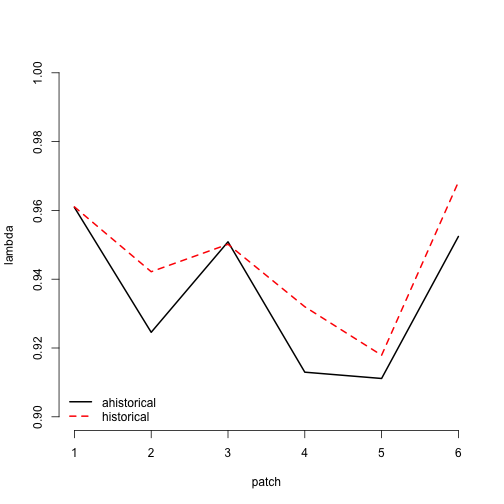

Figure 10. Ahistorical vs. historical lambda

```r
lambda2lnm <- lambda3(lathmat2lnmean)
lambda3lnm <- lambda3(lathmat3lnmean)

plot(lambda ~ patch, data = lambda2lnm[1:6,], ylim = c(0.90, 1.00), type = "l", lty= 1, lwd = 2, bty = "n")
lines(lambda ~ patch, data = lambda3lnm[1:6,], lty = 2, lwd= 2, col = "red")
legend("bottomleft", c("ahistorical", "historical"), lty = c(1, 2), col = c("black", "red"), lwd = 2, bty = "n")
```

Now let’s look at the stable stage distributions for both ahistorical and historical MPMs, using the population mean matrix. First, we will estimate the full distributions, and then compare the ahistorical stable stage distribution to the historically-corrected distribution. Note that our output for the ahistorical MPM match those produced by package `popbio`’s `stable.stage()` function.

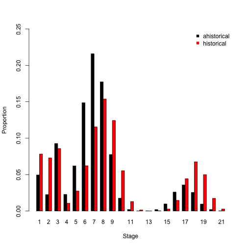

Figure 11. Ahistorical vs. historically-corrected stable stage distribution

```r
ehrlen2ss <- stablestage3(lathmat2lnmean)
ehrlen3ss <- stablestage3(lathmat3lnmean)

ss_put_together <- cbind.data.frame(subset(ehrlen2ss, matrix == 7)$ss_prop,
                                    subset(ehrlen3ss$ahist, matrix == 7)$ss_prop)
names(ss_put_together) <- c("ahist", "hist")
rownames(ss_put_together) <- subset(ehrlen2ss, matrix == 7)$stage_id

barplot(t(ss_put_together), beside=T, ylab = "Proportion", xlab = "Stage", ylim = c(0, 0.25),
        col = c("black", "red"), bty = "n")
legend("topright", c("ahistorical", "historical"), col = c("black", "red"), pch = 15, bty = "n")
```

The output for the ahistorical MPM is a dataframe with matrix of origin, stage name, and stable stage proportion in each row. We have 7 sets of stable stage distributions because there are 7 matrices. Note that the last matrix, the 7th, is the grand mean matrix, and that the `ss_prop` column, which gives us the stable stage proportion of each stage, sums to 1.0 within each matrix. In the historical case, output includes 2 data frames, the first (`$hist`) of which is the full historical stage-pair distribution, and the second (`$ahist`) is the historically-corrected stable stage distribution.

The ahistorical and historically-corrected distributions differ quite a bit. For example, dormant seeds make up 8% of the population in the historically-corrected stable stage distribution, but only 5% in the ahistorical case. Seedlings make up about 7% of the historically-corrected stable stage distribution but only 2% in the ahistorical case. Once again, we see an impact of individual history on an important characteristic of the dynamics of this population.

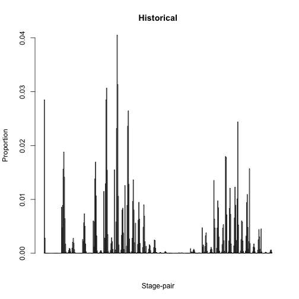

Figure 12. Historical stable stage distribution

```r
barplot(subset(ehrlen3ss$hist, matrix == 7)$ss_prop, main = "Historical", ylab = "Proportion", xlab = "Stage-pair")
```

Now let’s take a look at the reproductive values. We’ll go straight to the plots, as with the stable stage distribution.

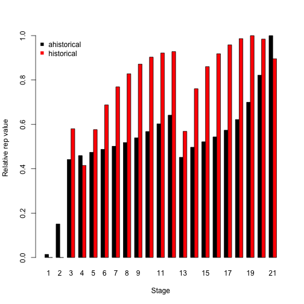

Figure 13. Ahistorical vs. historically-corrected reproductive values

```r
ehrlen2rv <- repvalue3(lathmat2lnmean)
ehrlen3rv <- repvalue3(lathmat3lnmean)

rv_put_together <- cbind.data.frame(subset(ehrlen2rv, matrix == 7)$rep_value,
                                    subset(ehrlen3rv$ahist, matrix == 7)$rep_value)
names(rv_put_together) <- c("ahist", "hist")
rv_put_together$ahist <- rv_put_together$ahist / max(rv_put_together$ahist)
rv_put_together$hist <- rv_put_together$hist / max(rv_put_together$hist)
rownames(rv_put_together) <- subset(ehrlen2rv, matrix == 7)$stage_id

barplot(t(rv_put_together), beside=T, ylab = "Relative rep value", xlab = "Stage",
        col = c("black", "red"), bty = "n")
legend("topleft", c("ahistorical", "historical"), col = c("black", "red"), pch = 15, bty = "n")
```

In the ahistorical case, the highest reproductive value appears to be associated with the largest flowering stage, Sz9r, while the lowest is associated with dormant seeds (as before, our `rep_value` estimates are similar to those estimated by `popbio`’s `reproductive.value()` function). These results are different from the historically-corrected case. Dormant seeds and seedlings appear to have essentially no reproductive value, and the smallest non-zero reproductive value is associated with Sz1nr, the smallest non-flowering adult. The highest reproductive value is now Sz7r, the a large flowering adult. We leave it to the reader to consider the importance of such differences.

We will next assess which matrix elements $\lambda$ is most sensitive and elastic to changes in. First the sensitivity of the grand mean ahistorical MPM.

```r
lathmat2msens <- sensitivity3(lathmat2lnmean)

writeLines("\nThe highest sensitivity value: ")
```

```
#>
#> The highest sensitivity value:
```

```r
max(lathmat2msens$sensmats[[7]][which(lathmat2lnmean$A[[7]] > 0)])
```

```
#> [1] 0.4536532
```

```r
writeLines("\nThis value is associated with element: ")
```

```
#>
#> This value is associated with element:
```

```r
which(lathmat2msens$sensmats[[7]] == max(lathmat2msens$sensmats[[7]][which(lathmat2lnmean$A[[7]] > 0)]))
```

```
#> [1] 147
```

The highest sensitivity value appears to be associated with the transition from 4-sprouted non-flowering adult to the largest flowering adult. Inspecting the sensitivity matrix (type `lathmat2msens$sensmats[[7]]` to inspect the full matrix) also shows that transitions near that element in the matrix are also associated with rather high sensitivities.

Now we can compare the historical case, particularly focusing on the historically-corrected sensitivities.

```r
lathmat3msens <- sensitivity3(lathmat3lnmean)

writeLines("\nThe highest sensitivity value: ")
```

```
#>
#> The highest sensitivity value:
```

```r
max(lathmat3msens$ah_sensmats[[7]][which(lathmat2lnmean$A[[7]] > 0)])
```

```
#> [1] 5.089945
```

```r
writeLines("\nThis value is associated with element: ")
```

```
#>
#> This value is associated with element:
```

```r
which(lathmat3msens$ah_sensmats[[7]] == max(lathmat3msens$ah_sensmats[[7]][which(lathmat2lnmean$A[[7]] > 0)]))
```

```
#> [1] 168
```

Let’s now assess the elasticity of $\lambda$ to matrix elements, comparing the ahistorical to the historically-corrected case.

```r
lathmat2melas <- elasticity3(lathmat2lnmean)
lathmat3melas <- elasticity3(lathmat3lnmean)

writeLines("\nThe largest ahistorical elasticity is associated with element: ")
```

```
#>
#> The largest ahistorical elasticity is associated with element:
```

```r
which(lathmat2melas$elasmats[[7]] == max(lathmat2melas$elasmats[[7]]))
```

```
#> [1] 133
```

```r
writeLines("\nThe largest historically-corrected elasticity is associated with element: ")
```

```
#>
#> The largest historically-corrected elasticity is associated with element:
```

```r
which(lathmat3melas$ah_elasmats[[7]] == max(lathmat3melas$ah_elasmats[[7]]))
```

```
#> [1] 155
```

Finally, let’s compare the elasticity of $\lambda$ in relation to the core life history stages, via a barplot comparison.

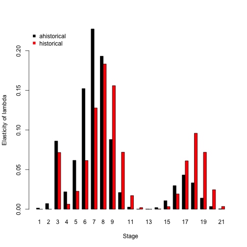

Figure 14. Ahistorical vs. historically-corrected elasticity of lambda to stage

```r
elas_put_together <- cbind.data.frame(colSums(lathmat2melas$elasmats[[7]]), colSums(lathmat3melas$ah_elasmats[[7]]))
names(elas_put_together) <- c("ahist", "hist")
rownames(elas_put_together) <- lathmat2melas$stages$stage_id

barplot(t(elas_put_together), beside=T, ylab = "Elasticity of lambda", xlab = "Stage",
        col = c("black", "red"), bty = "n")
legend("topleft", c("ahistorical", "historical"), col = c("black", "red"), pch = 15, bty = "n")
```

The barplots show that incorporating individual history leads to greater elasticity values in larger adults, and in flowering adults, than in the ahistorical case. Although the overall pattern looks similar, the two analyses nonetheless suggest a different importance to young vs. old, small vs. large, and to flowering vs. non-flowering.

## Acknowledgements

We are grateful to two anonymous reviewers whose scrutiny improved the quality of this vignette. The project resulting in this package and this tutorial was funded by Grant-In-Aid 19H03298 from the Japan Society for the Promotion of Science.

## Literature cited

Bartoń, Kamil A. 2014. “MuMIn: Multi-Model Inference.” https://CRAN.R-project.org/package=MuMIn.

Bates, Douglas, Martin Maechler, Ben Bolker, and Steve Walker. 2015. “Fitting Linear Mixed-Effects Models Using *Lme4*.” *Journal of Statistical Software* 67 (1): 1–48. https://doi.org/10.18637/jss.v067.i01.

Broek, Jan van den. 1995. “A Score Test for Zero Inflation in a Poisson Distribution.” *Biometrics* 51 (2): 738–43. https://doi.org/10.2307/2532959.

Burnham, Kenneth P., and David R. Anderson. 2002. *Model Selection and Multimodel Inference: A Practical Information-Theoretic Approach*. New York, New York, USA: Springer-Verlag New York, Inc.

Ehrlén, Johan. 1995. “Demography of the Perennial Herb *Lathyrus Vernus*. I. Herbivory and Individual Performance.” *Journal of Ecology* 83 (2): 287–95. https://doi.org/10.2307/2261567.

———. 2000. “The Dynamics of Plant Populations: Does the History of Individuals Matter?” *Ecology* 81 (6): 1675–84. https://doi.org/10.1890/0012-9658(2000)081[1675:TDOPPD]2.0.CO;2.

———. 2002. “Assessing the Lifetime Consequences of Plant-Animal Interactions for the Perennial Herb Lathyrus Vernus (Fabaceae).” *Perspectives in Plant Ecology, Evolution and Systematics* 5 (3): 145–63. https://doi.org/10.1078/1433-8319-00031.

Ehrlén, Johan, and Ove Eriksson. 1996. “Seedling Recruitment in the Perennial Herb Lathyrus Vernus.” *Flora* 191 (4): 377–83. https://doi.org/10.1016/S0367-2530(17)30744-2.

Ehrlén, Johan, and Kari Lehtilä. 2002. “How Perennal Are Perennial Plants?” *Oikos* 98: 308–22. https://doi.org/10.1034/j.1600-0706.2002.980212.x.

Ehrlén, Johan, and Zuzana Münzbergová. 2009. “Timing of Flowering: Opposed Selection on Different Fitness Components and Trait Covariation.” *The American Naturalist* 173 (6): 819–30. https://doi.org/10.1086/598492.

Ehrlén, Johan, and Jan Van Groenendael. 2001. “Storage and the Delayed Costs of Reproduction in the Understorey Perennial *Lathyrus Vernus*.” *Journal of Ecology* 89 (2): 237–46. https://doi.org/10.1046/j.1365-2745.2001.00546.x.

Shefferson, Richard P., Robert J. Warren II, and H. Ronald Pulliam. 2014. “Life History Costs Make Perfect Sprouting Maladaptive in Two Herbaceous Perennials.” *Journal of Ecology* 102 (5): 1318–28. https://doi.org/10.1111/1365-2745.12281.